# Practicum 2

## Problem 1 (50 pts)

### 1

(0 pts) Download the data set Census Income Data for Adults along with its explanation (Links to an external site.). There are two data sets (adult.data and adult.test). Note that the data file does not contain header names; you may wish to add those. The description of each column can be found in the data set explanation. Combine the two data sets into a single data set.

```r
adult_data <- read.csv("/Users/taylorjohnson/Downloads/adult.data")
adult_test <- read.csv("/Users/taylorjohnson/Downloads/adult.test", skip = 1)
names <- c("age", "workclass", "fnlwgt", "education", "education_num", "marital_status", "occupation", "relationship", "race", "sex", "capital_gain", "capital_loss", "hours_per_week", "native_country", "income")

#Change column names
colnames(adult_data) <- names
colnames(adult_test) <- names

#remove period in income columns
adult_test <- adult_test %>%
  mutate(income = str_replace(income, "\\.", ""))
```

```r
#combine datasets
adult_data_c <- rbind(adult_data, adult_test) %>%
  mutate(income = str_replace(income, ">", "greater than ")) %>%
  mutate(income = str_replace(income, "<=", "less than or equal to "))

#remove unknowns
adult_data_c <- data.frame(lapply(adult_data_c, function(x) {gsub("\\?", NA, x)  }))
adult_data_c <- adult_data_c %>%
  na.omit(.)
```

### 2

(0 pts) Explore the combined data set as you see fit and that allows you to get a sense of the data and get comfortable with it.

```r
str(adult_data_c)
```

```
## 'data.frame':    45220 obs. of  15 variables:
##  $ age           : chr  "50" "38" "53" "28" ...
##  $ workclass     : chr  " Self-emp-not-inc" " Private" " Private" " Private" ...
##  $ fnlwgt        : chr  "83311" "215646" "234721" "338409" ...
##  $ education     : chr  " Bachelors" " HS-grad" " 11th" " Bachelors" ...
##  $ education_num : chr  "13" "9" "7" "13" ...
##  $ marital_status: chr  " Married-civ-spouse" " Divorced" " Married-civ-spouse" " Married-civ-spouse" ...
##  $ occupation    : chr  " Exec-managerial" " Handlers-cleaners" " Handlers-cleaners" " Prof-specialty" ...
##  $ relationship  : chr  " Husband" " Not-in-family" " Husband" " Wife" ...
##  $ race          : chr  " White" " White" " Black" " Black" ...
##  $ sex           : chr  " Male" " Male" " Male" " Female" ...
##  $ capital_gain  : chr  "0" "0" "0" "0" ...
##  $ capital_loss  : chr  "0" "0" "0" "0" ...
##  $ hours_per_week: chr  "13" "40" "40" "40" ...
##  $ native_country: chr  " United-States" " United-States" " United-States" " Cuba" ...
##  $ income        : chr  " less than or equal to 50K" " less than or equal to 50K" " less than or equal to 50K" " less than or equal to 50K" ...
##  - attr(*, "na.action")= 'omit' Named int [1:3620] 14 27 38 51 61 69 77 93 106 128 ...
##   ..- attr(*, "names")= chr [1:3620] "14" "27" "38" "51" ...
```

### 3

(5 pts) Split the combined data set 70/30% so you retain 30% for validation and tuning using random sampling with replacement. Use a fixed seed so you produce the same results each time you run the code. Going forward you will use the 70% data set for training and the 30% data set for validation and determine accuracy.

```r
set.seed(123)

adult_data_c$income <- as.factor(adult_data_c$income)
trainIndex <- createDataPartition(adult_data_c$income, p = .70,
                                  list = FALSE,
                                  times = 1)
Train<- adult_data_c[trainIndex,]
Val <- adult_data_c[-trainIndex,]
```

```r
table(Train$income)
```

```
##
##           greater than 50K  less than or equal to 50K
##                       7846                      23809
```

```r
table(Val$income)
```

```
##
##           greater than 50K  less than or equal to 50K
##                       3362                      10203
```

```r
prop.table(table(Train$income))
```

```
##
##           greater than 50K  less than or equal to 50K
##                  0.2478597                  0.7521403
```

```r
prop.table(table(Val$income))
```

```
##
##           greater than 50K  less than or equal to 50K
##                  0.2478437                  0.7521563
```

proportions are similar

### 4

(8 pts) Using the Naive Bayes Classification algorithm from the KlaR package, build a binary classifier that predicts whether an individual earns more than or less than US$50,000. Only use the features age, education, workclass, sex, race, and native-country. Ignore any other features in your model. You need to transform continuous variables into categorical variables by binning (use equal size bins from min to max).

```r
#Select features and make bins for age
Train$age <- as.numeric(Train$age)
train_data <- Train %>%
  dplyr::select(age, education, workclass, sex, race, native_country, income) %>%
  mutate(age = if_else(age > 37, "Adult", "Younger Adults")) %>%
  mutate_all(as.factor)

Val$age <- as.numeric(Val$age)
val_data <- Val %>%
  dplyr::select(age, education, workclass, sex, race, native_country, income) %>%
  mutate(age = if_else(age > 37, "Adult", "Younger Adults")) %>%
  mutate_all(as.factor)
```

```r
prop.table(table(train_data$age))
```

```
##
##          Adult Younger Adults
##      0.4903807      0.5096193
```

```r
prop.table(table(val_data$age))
```

```
##
##          Adult Younger Adults
##      0.4917803      0.5082197
```

```r
# run Naive Bayes function
nbmodel <- NaiveBayes(income~age+education+workclass+sex+race+native_country, data=train_data)
```

```r
# check the accuracy
prediction <- predict(nbmodel, val_data)
```

### 5

(2 pts) Build a confusion matrix for the classifier from (4) and comment on it, e.g., explain what it means.

```r
caret::confusionMatrix(prediction$class, val_data$income)
```

```
## Confusion Matrix and Statistics
##
##                             Reference
## Prediction                    greater than 50K  less than or equal to 50K
##    greater than 50K                        516                        222
##    less than or equal to 50K              2846                       9981
##
##                Accuracy : 0.7738
##                  95% CI : (0.7667, 0.7808)
##     No Information Rate : 0.7522
##     P-Value [Acc > NIR] : 1.879e-09
##
##                   Kappa : 0.1784
##
##  Mcnemar's Test P-Value : < 2.2e-16
##
##             Sensitivity : 0.15348
##             Specificity : 0.97824
##          Pos Pred Value : 0.69919
##          Neg Pred Value : 0.77812
##              Prevalence : 0.24784
##          Detection Rate : 0.03804
##    Detection Prevalence : 0.05440
##       Balanced Accuracy : 0.56586
##
##        'Positive' Class :  greater than 50K
##
```

The accuracy is about 77%. The sensitivity is pretty low and specificity relatively high.

### 6

(8 pts) Create a full logistic regression model of the same features as in (4) (i.e., do not eliminate any features regardless of p-value). Be sure to either use dummy coding for categorical features or convert them to factor variables and ensure that the glm function does the dummy coding.

```r
#select fetures and convert characters to integers
train_data_lr <- Train %>%
  dplyr::select(age, education, workclass, sex, race, native_country, income) %>%
  mutate_if(is.character, as.factor) %>%
  mutate_if(is.factor, as.integer)

val_data_lr <- Val %>%
  dplyr::select(age, education, workclass, sex, race, native_country, income) %>%
  mutate_if(is.character, as.factor) %>%
  mutate_if(is.factor, as.integer)
```

```r
#convert income to factor
train_data_lr$income <- as.factor(train_data_lr$income)
val_data_lr$income <- as.factor(val_data_lr$income)
#create model
reg_model <- glm(income ~ age+education+workclass+sex+race+native_country, data=train_data_lr, family=binomial(link="logit"))
summary(reg_model)
```

```
##
## Call:
## glm(formula = income ~ age + education + workclass + sex + race +
##     native_country, family = binomial(link = "logit"), data = train_data_lr)
##
## Deviance Residuals:
##     Min       1Q   Median       3Q      Max
## -2.7345   0.2248   0.5507   0.7758   1.8808
##
## Coefficients:
##                 Estimate Std. Error z value Pr(>|z|)
## (Intercept)     6.489253   0.152807  42.467  < 2e-16 ***
## age            -0.042205   0.001066 -39.596  < 2e-16 ***
## education      -0.065565   0.003962 -16.550  < 2e-16 ***
## workclass       0.057507   0.014145   4.066 4.79e-05 ***
## sex            -1.264132   0.035632 -35.477  < 2e-16 ***
## race           -0.169358   0.019110  -8.862  < 2e-16 ***
## native_country -0.002634   0.002394  -1.100    0.271
## ---
## Signif. codes:  0 '***' 0.001 '**' 0.01 '*' 0.05 '.' 0.1 ' ' 1
##
## (Dispersion parameter for binomial family taken to be 1)
##
##     Null deviance: 35452  on 31654  degrees of freedom
## Residual deviance: 31805  on 31648  degrees of freedom
## AIC: 31819
##
## Number of Fisher Scoring iterations: 4
```

```r
# check the accuracy
prediction_lr <- predict(reg_model, newdata = val_data_lr, type = "response")
prediction_lr<-factor(ifelse(prediction_lr<0.5, 1, 2))
head(prediction_lr)
```

```
## 1 2 3 4 5 6
## 2 2 2 2 2 2
## Levels: 1 2
```

### 7

(2 pts) Build a confusion matrix for the classifier from (6) and comment on it, e.g., explain what it means.

```r
caret::confusionMatrix(prediction_lr, val_data_lr$income)
```

```
## Confusion Matrix and Statistics
##
##           Reference
## Prediction    1    2
##          1  325  467
##          2 3037 9736
##
##                Accuracy : 0.7417
##                  95% CI : (0.7342, 0.749)
##     No Information Rate : 0.7522
##     P-Value [Acc > NIR] : 0.9976
##
##                   Kappa : 0.0684
##
##  Mcnemar's Test P-Value : <2e-16
##
##             Sensitivity : 0.09667
##             Specificity : 0.95423
##          Pos Pred Value : 0.41035
##          Neg Pred Value : 0.76223
##              Prevalence : 0.24784
##          Detection Rate : 0.02396
##    Detection Prevalence : 0.05839
##       Balanced Accuracy : 0.52545
##
##        'Positive' Class : 1
##
```

The accuracy is a little bit lower than the naive bayes model. The sensitivity is terrible and specificity is very high

### 8

(8 pts) Create a Decision Tree model from rpart package, build a classifier that predicts whether an individual earns more than or less than US$50,000. Use the same features as (4). Make sure to transform categorical variables.

```r
tree_model <- rpart(income~age+education+workclass+sex+race+native_country, data=train_data_lr, method="class")
print(tree_model)
```

```
## n= 31655
##
## node), split, n, loss, yval, (yprob)
##       * denotes terminal node
##
##  1) root 31655 7846 2 (0.24785974 0.75214026)
##    2) age>=29.5 22518 7346 2 (0.32622791 0.67377209)
##      4) sex>=1.5 15950 6309 2 (0.39554859 0.60445141)
##        8) education>=7.5 14125 6106 2 (0.43228319 0.56771681)
##         16) education< 11.5 4479 1989 1 (0.55592766 0.44407234)
##           32) education>=9.5 3262 1248 1 (0.61741263 0.38258737) *
##           33) education< 9.5 1217  476 2 (0.39112572 0.60887428) *
##         17) education>=11.5 9646 3616 2 (0.37487041 0.62512959)
##           34) education>=12.5 4470 2222 1 (0.50290828 0.49709172)
##             68) education< 15.5 1539  423 1 (0.72514620 0.27485380) *
##             69) education>=15.5 2931 1132 2 (0.38621631 0.61378369) *
##           35) education< 12.5 5176 1368 2 (0.26429675 0.73570325) *
##        9) education< 7.5 1825  203 2 (0.11123288 0.88876712) *
##      5) sex< 1.5 6568 1037 2 (0.15788672 0.84211328) *
##    3) age< 29.5 9137  500 2 (0.05472256 0.94527744) *
```

```r
tree_predict <-  predict(tree_model, val_data_lr, type="class")
head(tree_predict)
```

```
## 1 2 3 4 5 6
## 2 2 2 2 2 2
## Levels: 1 2
```

### 9

(2 pts) Build a confusion matrix for the classifier from (8) and comment on it, e.g., explain what it means.

```r
caret::confusionMatrix(tree_predict, val_data_lr$income)
```

```
## Confusion Matrix and Statistics
##
##           Reference
## Prediction    1    2
##          1 1308  727
##          2 2054 9476
##
##                Accuracy : 0.795
##                  95% CI : (0.7881, 0.8018)
##     No Information Rate : 0.7522
##     P-Value [Acc > NIR] : < 2.2e-16
##
##                   Kappa : 0.3663
##
##  Mcnemar's Test P-Value : < 2.2e-16
##
##             Sensitivity : 0.38905
##             Specificity : 0.92875
##          Pos Pred Value : 0.64275
##          Neg Pred Value : 0.82186
##              Prevalence : 0.24784
##          Detection Rate : 0.09642
##    Detection Prevalence : 0.15002
##       Balanced Accuracy : 0.65890
##
##        'Positive' Class : 1
##
```

### 10

(10 pts) Build a function called predictEarningsClass() that predicts whether an individual makes more or less than US$50,000 and that combines the three predictive models from (4), (6), and (8) into a simple ensemble. If all three models disagree on a prediction, then the prediction should be the one from the model with the higher accuracy – make sure you do not hard code that as the training data may change over time and the same model may not be the more accurate forever.

```r
predictEarningsClass <- function(training_data, validation_data, testing_data){
    set.seed(123)
    #Naive Bayes
    nbmodel <- NaiveBayes(income~age+education+workclass+sex+race+native_country, data=training_data)
    #test data prediction
    nb_prediction <- predict(nbmodel, testing_data)
    nb_prediction <- as.integer(as.factor(nb_prediction$class))
    #validation prediction
    nb_val_prediction <- predict(nbmodel, validation_data)
    cm <- caret::confusionMatrix(nb_val_prediction$class, validation_data$income)
    nb_acc <- as.numeric(cm$overall[1])

    #convert data to numeric
    row_training <- nrow(training_data)
    training_data_b <- rbind(training_data, testing_data)
    train_data_c <- training_data_b %>%
    dplyr::select(age, education, workclass, sex, race, native_country, income) %>%
    mutate_if(is.character, as.factor) %>%
    mutate_if(is.factor, as.integer)
    training_data_c<- train_data_c[1:nrow(training_data), ]
    test_data_c <- train_data_c[row_training+1:nrow(train_data_c), ]
    test_data_c <- test_data_c %>% drop_na(age)

    val_data_c <- validation_data %>%
    dplyr::select(age, education, workclass, sex, race, native_country, income) %>%
    mutate_if(is.character, as.factor) %>%
    mutate_if(is.factor, as.integer)

   training_data_c$income <- as.factor(training_data_c$income)
   test_data_c$income <- as.factor(test_data_c$income)
   val_data_c$income <- as.factor(val_data_c$income)

   #binary logistic regression
   reg_model <- glm(income ~ age+education+workclass+sex+race+native_country, data=training_data_c, family=binomial(link="logit"))
   #test data prediction
   prediction_lr <- predict(reg_model, newdata = test_data_c, type = "response")
   lr_prediction<-factor(ifelse(prediction_lr<0.5, 1, 2))
   lr_prediction <- as.integer(lr_prediction)
   #validation data prediction
   prediction_lr_val <- predict(reg_model, newdata = val_data_c, type = "response")
   lr_val_prediction<-factor(ifelse(prediction_lr_val<0.5, 1, 2))
   cm <- caret::confusionMatrix(lr_val_prediction, val_data_c$income)
   lr_acc <- as.numeric(cm$overall[1])


   #decision tree
   tree_model <- rpart(income~age+education+workclass+sex+race+native_country, data=training_data_c, method="class")
   #test data prediction
   tree_prediction <-  predict(tree_model, test_data_c, type="class")
   tree_prediction <- as.integer(tree_prediction)
   #validation data predicition
   tree_prediction_val <-  predict(tree_model, val_data_c, type="class")
   cm <- caret::confusionMatrix(tree_prediction_val, val_data_c$income)
   tree_acc <- as.numeric(cm$overall[1])

   #accuracy of all three models
   accuracy <- data.frame(nb_acc, lr_acc, tree_acc)

  nb_lr <- nb_prediction == lr_prediction
  lr_tree <- lr_prediction == tree_prediction
  nb_tree <- nb_prediction == tree_prediction
  pred <- nb_lr == lr_tree
  pred <- lr_tree == nb_tree
  for (i in pred) {
    final_prediction = c()
    if (i == TRUE){
      prediction <- nb_prediction
      final_prediction <- c(final_prediction, prediction)
   }else {
       if (max(accuracy) == tree_acc){
           prediction <- tree_prediction
           final_prediction <- c(final_prediction, prediction)
           }
       if (max(accuracy) == nb_acc){
           prediction <- nb_prediction
           final_prediction <- c(final_prediction, prediction)
           }
       if (max(accuracy) == lr_acc){
           prediction <- lr_prediction
           final_prediction <- c(final_prediction, prediction)
           }
          }
        }
      final_prediction
}
```

```r
prediction_final <- predictEarningsClass(train_data, val_data, val_data)
head(prediction_final)
```

```
## [1] 2 2 2 2 2 2
```

```r
caret::confusionMatrix(as.factor(prediction_final),val_data_lr$income)
```

```
## Confusion Matrix and Statistics
##
##           Reference
## Prediction    1    2
##          1  516  222
##          2 2846 9981
##
##                Accuracy : 0.7738
##                  95% CI : (0.7667, 0.7808)
##     No Information Rate : 0.7522
##     P-Value [Acc > NIR] : 1.879e-09
##
##                   Kappa : 0.1784
##
##  Mcnemar's Test P-Value : < 2.2e-16
##
##             Sensitivity : 0.15348
##             Specificity : 0.97824
##          Pos Pred Value : 0.69919
##          Neg Pred Value : 0.77812
##              Prevalence : 0.24784
##          Detection Rate : 0.03804
##    Detection Prevalence : 0.05440
##       Balanced Accuracy : 0.56586
##
##        'Positive' Class : 1
##
```

### 11

(5 pts) Using the ensemble model from (10), predict whether a 47-year-old black female adult who is a local government worker with a Bachelor’s degree who immigrated from Honduras earns more or less than US$50,000.

```r
age <- "Adult"
education <- "Bachelors"
workclass <- "Local-gov"
sex <- "Female"
race <- "Black"
native_country <- "Honduras"
income <- NA
test <- data.frame(age, education, workclass, sex, race, native_country, income)
```

```r
prediction_final_test <- predictEarningsClass(train_data, val_data, test)
prediction_final_test
```

```
## [1] 2
```

## Problem 2 (50 pts)

### 1

(0 pts) Load and then explore this data set on car sales download into a dataframe called cars.df. Exclude name (manufacturer and model) from the data – do not use in any of the modeling going forward.

```r
cars.df <- read.csv("/Users/taylorjohnson/Downloads/CarDataSet.csv")
cars.df <- cars.df[,-1]
str(cars.df)
```

```
## 'data.frame':    4340 obs. of  7 variables:
##  $ year         : int  2007 2007 2012 2017 2014 2007 2016 2014 2015 2017 ...
##  $ selling_price: int  60000 135000 600000 250000 450000 140000 550000 240000 850000 365000 ...
##  $ km_driven    : int  70000 50000 100000 46000 141000 125000 25000 60000 25000 78000 ...
##  $ fuel         : chr  "Petrol" "Petrol" "Diesel" "Petrol" ...
##  $ seller_type  : chr  "Individual" "Individual" "Individual" "Individual" ...
##  $ transmission : chr  "Manual" "Manual" "Manual" "Manual" ...
##  $ owner        : chr  "First Owner" "First Owner" "First Owner" "First Owner" ...
```

### 2

(3 pts) Are there outliers in any one of the features in the data set? How do you identify outliers? Remove them but create a second data set with outliers removed called cars.no.df. Keep the original data set cars.df.

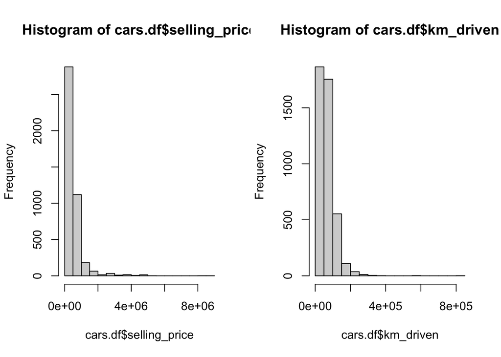

```r
par(mfrow = c(1, 2))
hist(cars.df$selling_price)
hist(cars.df$km_driven)
```

From the plots we can see that there are some outliers

```r
#check outliers for numeric data
selling_price_o <- abs((mean(cars.df$selling_price) - cars.df$selling_price)/sd(cars.df$selling_price))
selling_price_outliers <- cars.df[which(selling_price_o > 1.5), ]

km_driven_o <- abs((mean(cars.df$km_driven) - cars.df$km_driven)/sd(cars.df$km_driven))
km_driven_outliers <- cars.df[which(km_driven_o > 1.5), ]

nrow(selling_price_outliers)
```

```
## [1] 194
```

```r
nrow(km_driven_outliers)
```

```
## [1] 233
```

```r
outliers <- rbind(selling_price_outliers, km_driven_outliers)
```

The selling price column has 194 outliers and km driven has 233 outliers.

```r
#data with outliers removed
cars.no.df <- anti_join(cars.df, outliers)
```

### 3

(4 pts) Using pairs.panel, what are the distributions of each of the features in the data set with outliers removed (cars.no.df)? Are they reasonably normal so you can apply a statistical learner such as regression? Can you normalize features through a log, inverse, or square-root transform? State which features should be transformed and then transform as needed and build a new data set, cars.tx.

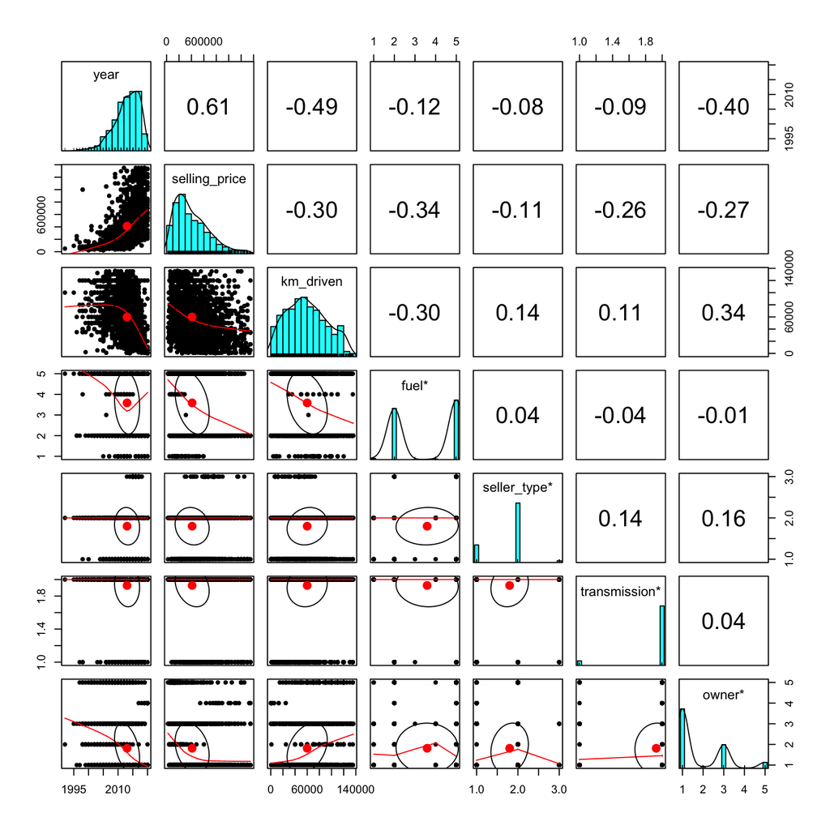

```r
pairs.panels(cars.no.df)
```

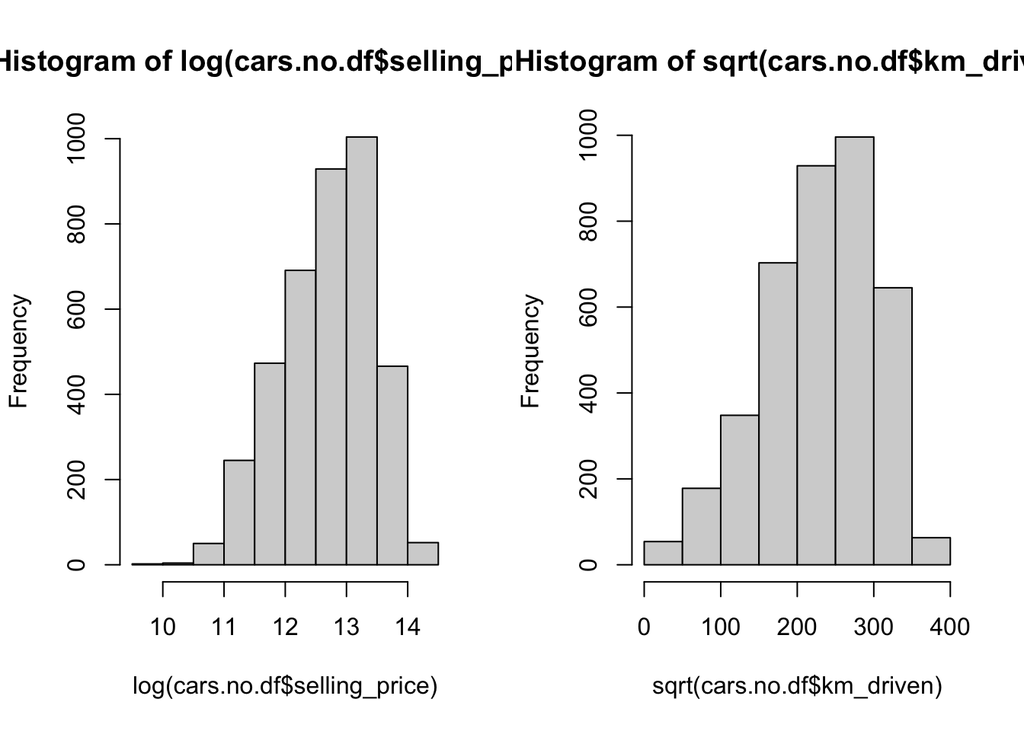

```r
par(mfrow = c(1, 2))
hist(log(cars.no.df$selling_price))
hist(sqrt(cars.no.df$km_driven))
```

```r
cars.tx <- cars.no.df
cars.tx$selling_price <- log(cars.tx$selling_price)
cars.tx$km_driven <- sqrt(cars.tx$km_driven)
```

The selling price was log transformed and km_driven was sqrt transformed so that the data looks reasonably normal.

### 4

(3 pts) What are the correlations to the response variable (km_driven) for cars.no.df? Are there collinearities? Build a full correlation matrix.

```r
cars.no.df <- cars.no.df %>%
  mutate_if(is.character, as.factor) %>%
  mutate_if(is.factor, as.integer)
cor(cars.no.df)
```

```
##                      year selling_price  km_driven        fuel seller_type
## year           1.00000000     0.6083225 -0.4851143 -0.11863006 -0.08310315
## selling_price  0.60832246     1.0000000 -0.3038188 -0.34375666 -0.11207968
## km_driven     -0.48511432    -0.3038188  1.0000000 -0.29526518  0.14039150
## fuel          -0.11863006    -0.3437567 -0.2952652  1.00000000  0.03681870
## seller_type   -0.08310315    -0.1120797  0.1403915  0.03681870  1.00000000
## transmission  -0.08517912    -0.2631334  0.1079144 -0.04455901  0.14328982
## owner         -0.40446363    -0.2740439  0.3428074 -0.01269060  0.15797621
##               transmission       owner
## year           -0.08517912 -0.40446363
## selling_price  -0.26313340 -0.27404389
## km_driven       0.10791441  0.34280741
## fuel           -0.04455901 -0.01269060
## seller_type     0.14328982  0.15797621
## transmission    1.00000000  0.04011046
## owner           0.04011046  1.00000000
```

Year has a high correlation with selling_price and km_driven which may cause collinearity.

### 5

(5 pts) Split each of the three data sets, cars.no.df, cars.df, and cars.tx 75%/25% so you retain 25% for testing using random sampling without replacement. Call the data sets, cars.training and cars.testing, cars.no.training and cars.no.testing, and cars.tx.training and cars.tx.testing.

```r
set.seed(123)
#partition cars.df
cars.df <- cars.df %>%
  mutate_if(is.character, as.factor) %>%
  mutate_if(is.factor, as.integer)
trainIndex <- createDataPartition(cars.df$km_driven, p = .75,
                                  list = FALSE,
                                  times = 1)
cars.training<- cars.df[trainIndex,]
cars.testing <- cars.df[-trainIndex,]
```

```r
#partition cars.no.df
trainIndex <- createDataPartition(cars.no.df$km_driven, p = .75,
                                  list = FALSE,
                                  times = 1)
cars.no.training<- cars.no.df[trainIndex,]
cars.no.testing <- cars.no.df[-trainIndex,]
```

```r
#partition cars.tx
cars.tx <- cars.tx %>%
  mutate_if(is.character, as.factor) %>%
  mutate_if(is.factor, as.integer)
trainIndex <- createDataPartition(cars.tx$km_driven, p = .75,
                                  list = FALSE,
                                  times = 1)
cars.tx.training<- cars.tx[trainIndex,]
cars.tx.testing <- cars.tx[-trainIndex,]
```

### 6

(10 pts) Build three ideal multiple regression models for cars.training, cars.no.training, and cars.tx.training using backward elimination based on p-value for predicting km_driven.

```r
#linear regression cars.df
model.cars.df <- lm(km_driven ~year+selling_price+fuel+seller_type+transmission+owner, data = cars.training)
summary(model.cars.df)
```

```
##
## Call:
## lm(formula = km_driven ~ year + selling_price + fuel + seller_type +
##     transmission + owner, data = cars.training)
##
## Residuals:
##     Min      1Q  Median      3Q     Max
## -145150  -21205   -5678   15214  745402
##
## Coefficients:
##                 Estimate Std. Error t value Pr(>|t|)
## (Intercept)    8.216e+06  3.913e+05  20.997  < 2e-16 ***
## year          -4.038e+03  1.944e+02 -20.766  < 2e-16 ***
## selling_price -8.054e-03  1.551e-03  -5.193 2.20e-07 ***
## fuel          -1.063e+04  4.777e+02 -22.252  < 2e-16 ***
## seller_type    4.924e+03  1.532e+03   3.214  0.00132 **
## transmission   1.223e+03  2.726e+03   0.449  0.65378
## owner          4.070e+03  6.229e+02   6.534 7.41e-11 ***
## ---
## Signif. codes:  0 '***' 0.001 '**' 0.01 '*' 0.05 '.' 0.1 ' ' 1
##
## Residual standard error: 39270 on 3249 degrees of freedom
## Multiple R-squared:  0.299,  Adjusted R-squared:  0.2977
## F-statistic: 230.9 on 6 and 3249 DF,  p-value: < 2.2e-16
```

```r
#remove transmission
model.cars.df <- lm(km_driven ~year+selling_price+fuel+seller_type+owner, data = cars.training)
summary(model.cars.df)
```

```
##
## Call:
## lm(formula = km_driven ~ year + selling_price + fuel + seller_type +
##     owner, data = cars.training)
##
## Residuals:
##     Min      1Q  Median      3Q     Max
## -145102  -21260   -6001   15257  745560
##
## Coefficients:
##                 Estimate Std. Error t value Pr(>|t|)
## (Intercept)    8.206e+06  3.905e+05  21.011  < 2e-16 ***
## year          -4.031e+03  1.939e+02 -20.793  < 2e-16 ***
## selling_price -8.414e-03  1.327e-03  -6.341 2.60e-10 ***
## fuel          -1.066e+04  4.738e+02 -22.492  < 2e-16 ***
## seller_type    5.004e+03  1.521e+03   3.289  0.00101 **
## owner          4.061e+03  6.225e+02   6.524 7.91e-11 ***
## ---
## Signif. codes:  0 '***' 0.001 '**' 0.01 '*' 0.05 '.' 0.1 ' ' 1
##
## Residual standard error: 39270 on 3250 degrees of freedom
## Multiple R-squared:  0.2989, Adjusted R-squared:  0.2978
## F-statistic: 277.2 on 5 and 3250 DF,  p-value: < 2.2e-16
```

```r
#regression cars.no.df
model.cars.no.df <- lm(km_driven ~year+selling_price+fuel+seller_type+transmission+owner, data = cars.no.training)
summary(model.cars.no.df)
```

```
##
## Call:
## lm(formula = km_driven ~ year + selling_price + fuel + seller_type +
##     transmission + owner, data = cars.no.training)
##
## Residuals:
##    Min     1Q Median     3Q    Max
## -95884 -17353  -2555  16530  90372
##
## Coefficients:
##                 Estimate Std. Error t value Pr(>|t|)
## (Intercept)    5.731e+06  2.962e+05  19.350  < 2e-16 ***
## year          -2.806e+03  1.476e+02 -19.013  < 2e-16 ***
## selling_price -2.118e-02  2.412e-03  -8.782  < 2e-16 ***
## fuel          -8.904e+03  3.399e+02 -26.195  < 2e-16 ***
## seller_type    6.119e+03  1.070e+03   5.720 1.17e-08 ***
## transmission  -2.475e+02  1.909e+03  -0.130    0.897
## owner          3.710e+03  4.228e+02   8.776  < 2e-16 ***
## ---
## Signif. codes:  0 '***' 0.001 '**' 0.01 '*' 0.05 '.' 0.1 ' ' 1
##
## Residual standard error: 25480 on 2932 degrees of freedom
## Multiple R-squared:  0.4112, Adjusted R-squared:   0.41
## F-statistic: 341.3 on 6 and 2932 DF,  p-value: < 2.2e-16
```

```r
#remove transmission
model.cars.no.df <- lm(km_driven ~year+selling_price+fuel+seller_type+owner, data = cars.no.training)
summary(model.cars.no.df)
```

```
##
## Call:
## lm(formula = km_driven ~ year + selling_price + fuel + seller_type +
##     owner, data = cars.no.training)
##
## Residuals:
##    Min     1Q Median     3Q    Max
## -95910 -17337  -2570  16526  90379
##
## Coefficients:
##                 Estimate Std. Error t value Pr(>|t|)
## (Intercept)    5.735e+06  2.946e+05  19.466  < 2e-16 ***
## year          -2.808e+03  1.466e+02 -19.156  < 2e-16 ***
## selling_price -2.109e-02  2.304e-03  -9.152  < 2e-16 ***
## fuel          -8.896e+03  3.348e+02 -26.571  < 2e-16 ***
## seller_type    6.100e+03  1.060e+03   5.757 9.45e-09 ***
## owner          3.711e+03  4.226e+02   8.783  < 2e-16 ***
## ---
## Signif. codes:  0 '***' 0.001 '**' 0.01 '*' 0.05 '.' 0.1 ' ' 1
##
## Residual standard error: 25470 on 2933 degrees of freedom
## Multiple R-squared:  0.4112, Adjusted R-squared:  0.4102
## F-statistic: 409.7 on 5 and 2933 DF,  p-value: < 2.2e-16
```

```r
#regression cars.tx
model.cars.tx <- lm(km_driven ~year+selling_price+fuel+seller_type+transmission+owner, data = cars.tx.training)
summary(model.cars.tx)
```

```
##
## Call:
## lm(formula = km_driven ~ year + selling_price + fuel + seller_type +
##     transmission + owner, data = cars.tx.training)
##
## Residuals:
##     Min      1Q  Median      3Q     Max
## -337.14  -34.66    2.79   39.33  187.42
##
## Coefficients:
##                 Estimate Std. Error t value Pr(>|t|)
## (Intercept)   14568.6556   767.5337  18.981  < 2e-16 ***
## year             -7.0295     0.3923 -17.916  < 2e-16 ***
## selling_price   -12.6781     2.3675  -5.355 9.21e-08 ***
## fuel            -19.1633     0.7818 -24.511  < 2e-16 ***
## seller_type      12.2001     2.3841   5.117 3.30e-07 ***
## transmission      5.7898     4.3234   1.339    0.181
## owner             6.8031     0.9637   7.059 2.08e-12 ***
## ---
## Signif. codes:  0 '***' 0.001 '**' 0.01 '*' 0.05 '.' 0.1 ' ' 1
##
## Residual standard error: 57.75 on 2932 degrees of freedom
## Multiple R-squared:  0.4076, Adjusted R-squared:  0.4064
## F-statistic: 336.3 on 6 and 2932 DF,  p-value: < 2.2e-16
```

```r
#remove transmission
model.cars.tx <- lm(km_driven ~year+selling_price+fuel+seller_type+owner, data = cars.tx.training)
summary(model.cars.tx)
```

```
##
## Call:
## lm(formula = km_driven ~ year + selling_price + fuel + seller_type +
##     owner, data = cars.tx.training)
##
## Residuals:
##     Min      1Q  Median      3Q     Max
## -336.50  -34.52    2.63   39.74  187.18
##
## Coefficients:
##                 Estimate Std. Error t value Pr(>|t|)
## (Intercept)   14436.3937   761.2560  18.964  < 2e-16 ***
## year             -6.9527     0.3882 -17.911  < 2e-16 ***
## selling_price   -13.5564     2.2751  -5.959 2.85e-09 ***
## fuel            -19.3389     0.7709 -25.088  < 2e-16 ***
## seller_type      12.5712     2.3683   5.308 1.19e-07 ***
## owner             6.7596     0.9633   7.017 2.80e-12 ***
## ---
## Signif. codes:  0 '***' 0.001 '**' 0.01 '*' 0.05 '.' 0.1 ' ' 1
##
## Residual standard error: 57.76 on 2933 degrees of freedom
## Multiple R-squared:  0.4073, Adjusted R-squared:  0.4063
## F-statistic:   403 on 5 and 2933 DF,  p-value: < 2.2e-16
```

### 7

(5 pts) Build a Regression Tree model using rpart package for predicting km_driven: one with cars.training, one with cars.no.training, and one with cars.tx.training, i.e., regression models that contains all features.

```r
#cars.training
cars.training.tree <- rpart(km_driven ~ year+selling_price+fuel+seller_type+transmission+owner, data = cars.training)
cars.training.tree.pred <- predict(cars.training.tree, cars.testing)
head(as.numeric(cars.training.tree.pred))
```

```
## [1] 41280.13 59162.51 41280.13 78088.08 59162.51 41280.13
```

```r
head(cars.testing$km_driven)
```

```
## [1] 25000 60000 35000 70000 60000 35000
```

```r
#cars.no.training
cars.no.training.tree <- rpart(km_driven ~ year+selling_price+fuel+seller_type+transmission+owner, data = cars.no.training)
cars.no.training.tree.pred <- predict(cars.no.training.tree, cars.no.testing)
head(as.numeric(cars.no.training.tree.pred))
```

```
## [1] 72858.45 55414.60 26393.62 53316.47 53316.47 26393.62
```

```r
head(cars.no.testing$km_driven)
```

```
## [1]  70000  78000  46000  60000 100000  15000
```

```r
#cars.tx.training
cars.tx.training.tree <- rpart(km_driven ~ year+selling_price+fuel+seller_type+transmission+owner, data = cars.tx.training)
cars.tx.training.tree.pred <- predict(cars.tx.training.tree, cars.tx.testing)
head(as.numeric(cars.tx.training.tree.pred)^2)
```

```
## [1] 71135.66 71135.66 30079.24 71135.66 30079.24 49723.69
```

```r
head((cars.tx.testing$km_driven)^2)
```

```
## [1] 70000 50000 25000 50000 46000 35000
```

### 8

(10 pts) Provide an analysis of the 6 models (using their respective testing data sets), including Adjusted R-Squared and RMSE. Which of these models is the best? Why?

```r
#linear regression cars.df
prediction.cars.df <- predict(model.cars.df, newdata = cars.testing, type = "response")
cars.df.rsme <- sqrt(mean((cars.testing$km_driven - prediction.cars.df)^2))
cars.df.rsme
```

```
## [1] 36480.26
```

The rsq is 0.298 and rsme is 36480.

```r
#regression tree cars.df
tree.cars.df.rsme <- sqrt(mean((cars.testing$km_driven - cars.training.tree.pred)^2))
tree.cars.df.rsme
```

```
## [1] 36145.85
```

```r
#r-squared
summ <- printcp(cars.training.tree)
```

```
##
## Regression tree:
## rpart(formula = km_driven ~ year + selling_price + fuel + seller_type +
##     transmission + owner, data = cars.training)
##
## Variables actually used in tree construction:
## [1] fuel          seller_type   selling_price year
##
## Root node error: 7.1473e+12/3256 = 2195129856
##
## n= 3256
##
##         CP nsplit rel error  xerror     xstd
## 1 0.187932      0   1.00000 1.00080 0.097579
## 2 0.041493      1   0.81207 0.82132 0.096592
## 3 0.035173      2   0.77058 0.77804 0.098200
## 4 0.022799      3   0.73540 0.75465 0.097596
## 5 0.022609      4   0.71260 0.73799 0.096822
## 6 0.010814      5   0.68999 0.70286 0.094110
## 7 0.010162      6   0.67918 0.70509 0.093610
## 8 0.010000      8   0.65886 0.70245 0.093598
```

```r
rsq <- 1-summ[,c(3,4)]
rsq[nrow(rsq),1]
```

```
## [1] 0.3411445
```

The rsq is 0.341 and the rsme is 36146.

```r
#Linear regression cars.no.df
prediction.cars.no.df <- predict(model.cars.no.df, newdata = cars.no.testing, type = "response")
cars.no.df.rsme <- sqrt(mean((cars.no.testing$km_driven - prediction.cars.no.df)^2))
cars.no.df.rsme
```

```
## [1] 25739.59
```

The rsq is 0.4102 and the rsme is 25740.

```r
#regression tree cars.no.df
tree.cars.no.df.rsme <- sqrt(mean((cars.no.testing$km_driven - cars.no.training.tree.pred)^2))
tree.cars.no.df.rsme
```

```
## [1] 25630.3
```

```r
#r-squared
summ <- printcp(cars.no.training.tree)
```

```
##
## Regression tree:
## rpart(formula = km_driven ~ year + selling_price + fuel + seller_type +
##     transmission + owner, data = cars.no.training)
##
## Variables actually used in tree construction:
## [1] fuel        seller_type year
##
## Root node error: 3.2327e+12/2939 = 1099934180
##
## n= 2939
##
##         CP nsplit rel error  xerror     xstd
## 1 0.271598      0   1.00000 1.00072 0.019994
## 2 0.047743      1   0.72840 0.72909 0.017362
## 3 0.030282      2   0.68066 0.68171 0.017147
## 4 0.028898      3   0.65038 0.66456 0.016871
## 5 0.024329      4   0.62148 0.63445 0.016400
## 6 0.019205      5   0.59715 0.61221 0.016066
## 7 0.010000      6   0.57795 0.58895 0.015793
```

```r
rsq <- 1-summ[,c(3,4)]
rsq[nrow(rsq),1]
```

```
## [1] 0.4220541
```

The rsq is 0.422 and the rsme is 25630.

```r
#linear regression cars.tx
prediction.cars.tx <- predict(model.cars.tx, newdata = cars.tx.testing, type = "response")
cars.tx.rsme <- sqrt(mean((cars.tx.testing$km_driven^2 - prediction.cars.tx^2)^2))
cars.tx.rsme
```

```
## [1] 26806.85
```

The rsq is 0.4063 and the rsme is 26807.

```r
#regression tree cars.tx
tree.cars.tx.df.rsme <- sqrt(mean((cars.tx.testing$km_driven^2 - cars.tx.training.tree.pred^2)^2))
tree.cars.tx.df.rsme
```

```
## [1] 25650.34
```

```r
#r-squared
summ <- printcp(cars.tx.training.tree)
```

```
##
## Regression tree:
## rpart(formula = km_driven ~ year + selling_price + fuel + seller_type +
##     transmission + owner, data = cars.tx.training)
##
## Variables actually used in tree construction:
## [1] fuel        seller_type year
##
## Root node error: 16508386/2939 = 5617
##
## n= 2939
##
##         CP nsplit rel error  xerror     xstd
## 1 0.284167      0   1.00000 1.00089 0.023792
## 2 0.051717      1   0.71583 0.72084 0.019718
## 3 0.036599      2   0.66412 0.66855 0.018690
## 4 0.029339      3   0.62752 0.63121 0.019039
## 5 0.029129      4   0.59818 0.61487 0.018876
## 6 0.019606      5   0.56905 0.57733 0.018258
## 7 0.010957      6   0.54944 0.55873 0.016901
## 8 0.010000      7   0.53849 0.55217 0.017397
```

```r
rsq <- 1-summ[,c(3,4)]
rsq[nrow(rsq),1]
```

```
## [1] 0.4615133
```

The rsq is 0.461 and the rsme is 25650

The regression trees have larger adjusted rsq values than the linear regression models. The tx.df, which had outliers removed and data looked the most normal, regression tree has a low rsme and highest adjusted rsq making it the best model. The worst models are using the cars.df which did not have outliers removed and data was not transformed.

### 9

(5 pts) Using each of the regression models, what are the predicted odometer readings (km_driven) of a 2004 vehicle that was sold by a dealer for R87,000, has a Diesel engine, a manual transmission, and is second owner? Why are the predictions different?

```r
#cars.df linear regression
year <- 2004
selling_price <- 87000
fuel <- 2
seller_type <- 1
owner <- 3

df <- data.frame(year, selling_price, fuel, seller_type, owner)

#predicted grade using final model
p.km.df <- predict(model.cars.df, newdata=df, type="response")
p.km.df
```

```
##        1
## 122660.5
```

```r
#cars.df regression tree
#predicted grade using final model
transmission <- 2
df.tree <- data.frame(year, selling_price, fuel, seller_type, transmission, owner)
p.km.df.tree <- predict(cars.training.tree, df.tree)
p.km.df.tree
```

```
##        1
## 71492.67
```

```r
#cars.no.df linear regression
#predicted grade using final model
p.km.no.df <- predict(model.cars.no.df, newdata=df, type="response")
p.km.no.df
```

```
##        1
## 105785.1
```

```r
#cars.no.df regression tree
df.tree <- data.frame(year, selling_price, fuel, seller_type, transmission, owner)
p.km.no.df.tree <- predict(cars.no.training.tree, df.tree)
p.km.no.df.tree
```

```
##        1
## 64819.26
```

```r
#cars.tx prediction
year <- 2004
selling_price <- log(87000)
fuel <- 2
seller_type <- 1
owner <- 3

df.tx <- data.frame(year, selling_price, fuel, seller_type, owner)

#predicted grade using final model
p.km.tx <- predict(model.cars.tx, newdata=df.tx, type="response")
p.km.tx^2
```

```
##        1
## 117778.7
```

```r
df.tx.tree <- data.frame(year, selling_price, fuel, seller_type, transmission, owner)
p.km.tx.df.tree <- predict(cars.tx.training.tree, df.tx.tree)
p.km.tx.df.tree^2
```

```
##        1
## 60506.62
```

The linear regression predictions are similar to each other and the regression tree predictions are similar to each other. The predictions between the two types of models are pretty far off but are inside the prediction interval in question 10. The regression trees include the transmission variable which could cause differences in the predictions. The data that is transformed and has outliers removed is going to have a different prediction becuase it is a better model.

### 10

(5 pts) For each of the predictions, calculate the 95% prediction interval for the kilometers driven.

```r
#cars.df linear regression
predict(model.cars.df, newdata = df, interval = "prediction")
```

```
##        fit      lwr      upr
## 1 122660.5 45542.72 199778.4
```

```r
#cars.no.df linear regression
predict(model.cars.no.df, newdata = df, interval = "prediction")
```

```
##        fit      lwr      upr
## 1 105785.1 55739.04 155831.2
```

```r
#cars.tx linear regression
pred_int <- predict(model.cars.tx, newdata = df.tx, interval = "prediction")
pred_int^2
```

```
##        fit      lwr    upr
## 1 117778.7 52763.02 208553
```